# Steam Games Analysis

### Introduction

We are provided with a Steam Games Dataset,providing a rich tapestry of insights into the PC gaming realm. Our analysis delves into the dynamic interplay of genres, ownership statistics, and player engagement metrics, aiming to decipher the evolving landscape of gaming preferences and how game developers could benefit from this and tried to dig out many trends.

### Importing useful libraries

```python
import pandas as pd
import numpy as np
import matplotlib.pyplot as plt
import seaborn as sns
```

### Loading the dataset

```python
dtype_dict = {'int_col': int, 'str_col': str}
data = pd.read_csv("SteamOG.csv", dtype=dtype_dict, low_memory=False)
```

```python
data
```

|  | AppID | Name | Release date | Estimated owners | Peak CCU | Required age | Price | DLC count | About the game | Supported languages | ... | Average playtime two weeks | Median playtime forever | Median playtime two weeks | Developers | Publishers | Categories | Genres | Tags | Screenshots | Movies |
| --- | --- | --- | --- | --- | --- | --- | --- | --- | --- | --- | --- | --- | --- | --- | --- | --- | --- | --- | --- | --- | --- |
| 0 | 20200 | Galactic Bowling | Oct 21, 2008 | 0 - 20000 | 0 | 0 | 19.99 | 0 | Galactic Bowling is an exaggerated and stylize... | ['English'] | ... | 0 | 0 | 0 | Perpetual FX Creative | Perpetual FX Creative | Single-player,Multi-player,Steam Achievements,... | Casual,Indie,Sports | Indie,Casual,Sports,Bowling | https://cdn.akamai.steamstatic.com/steam/apps/... | http://cdn.akamai.steamstatic.com/steam/apps/2... |
| 1 | 655370 | Train Bandit | Oct 12, 2017 | 0 - 20000 | 0 | 0 | 0.99 | 0 | THE LAW!! Looks to be a showdown atop a train.... | ['English', 'French', 'Italian', 'German', 'Sp... | ... | 0 | 0 | 0 | Rusty Moyher | Wild Rooster | Single-player,Steam Achievements,Full controll... | Action,Indie | Indie,Action,Pixel Graphics,2D,Retro,Arcade,Sc... | https://cdn.akamai.steamstatic.com/steam/apps/... | http://cdn.akamai.steamstatic.com/steam/apps/2... |
| 2 | 1732930 | Jolt Project | Nov 17, 2021 | 0 - 20000 | 0 | 0 | 4.99 | 0 | Jolt Project: The army now has a new robotics ... | ['English', 'Portuguese - Brazil'] | ... | 0 | 0 | 0 | Campião Games | Campião Games | Single-player | Action,Adventure,Indie,Strategy | NaN | https://cdn.akamai.steamstatic.com/steam/apps/... | http://cdn.akamai.steamstatic.com/steam/apps/2... |
| 3 | 1355720 | Henosis™ | Jul 23, 2020 | 0 - 20000 | 0 | 0 | 5.99 | 0 | HENOSIS™ is a mysterious 2D Platform Puzzler w... | ['English', 'French', 'Italian', 'German', 'Sp... | ... | 0 | 0 | 0 | Odd Critter Games | Odd Critter Games | Single-player,Full controller support | Adventure,Casual,Indie | 2D Platformer,Atmospheric,Surreal,Mystery,Puzz... | https://cdn.akamai.steamstatic.com/steam/apps/... | http://cdn.akamai.steamstatic.com/steam/apps/2... |
| 4 | 1139950 | Two Weeks in Painland | Feb 3, 2020 | 0 - 20000 | 0 | 0 | 0.00 | 0 | ABOUT THE GAME Play as a hacker who has arrang... | ['English', 'Spanish - Spain'] | ... | 0 | 0 | 0 | Unusual Games | Unusual Games | Single-player,Steam Achievements | Adventure,Indie | Indie,Adventure,Nudity,Violent,Sexual Content,... | https://cdn.akamai.steamstatic.com/steam/apps/... | http://cdn.akamai.steamstatic.com/steam/apps/2... |
| ... | ... | ... | ... | ... | ... | ... | ... | ... | ... | ... | ... | ... | ... | ... | ... | ... | ... | ... | ... | ... | ... |
| 85098 | 2669080 | Mannerheim's Saloon Car | Jan 2, 2024 | 0 - 0 | 0 | 0 | 0.00 | 0 | Marshal Mannerheim’s Saloon Car is the train c... | ['English', 'Finnish'] | ... | 0 | 0 | 0 | Xamk Game Studios | Sodan ja rauhan keskus Muisti, Päämajamuseo | Single-player,Tracked Controller Support,VR Only | Adventure,Simulation | NaN | https://cdn.akamai.steamstatic.com/steam/apps/... | http://cdn.akamai.steamstatic.com/steam/apps/2... |
| 85099 | 2736910 | Beer Run | Jan 3, 2024 | 0 - 0 | 0 | 0 | 0.00 | 0 | Beer Run is an Indie game created to steal bee... | ['English'] | ... | 0 | 0 | 0 | 955 Games | 955 Games | Single-player | Casual,Indie | NaN | https://cdn.akamai.steamstatic.com/steam/apps/... | http://cdn.akamai.steamstatic.com/steam/apps/2... |
| 85100 | 2743220 | My Friend The Spider | Jan 4, 2024 | 0 - 0 | 0 | 0 | 0.00 | 0 | A small 'horror' narrative game about isolatio... | ['English'] | ... | 0 | 0 | 0 | MCA | MCA | Single-player | Adventure,Simulation | NaN | https://cdn.akamai.steamstatic.com/steam/apps/... | http://cdn.akamai.steamstatic.com/steam/apps/2... |
| 85101 | 2293130 | Path of Survivors | Jan 8, 2024 | 0 - 0 | 0 | 0 | 3.99 | 0 | Path of Survivors is a multi-class auto-battle... | ['English'] | ... | 0 | 0 | 0 | Limited Input | Limited Input | Single-player,Steam Achievements,Partial Contr... | Action,Casual,Indie,RPG,Simulation | NaN | https://cdn.akamai.steamstatic.com/steam/apps/... | http://cdn.akamai.steamstatic.com/steam/apps/2... |
| 85102 | 2738840 | The Night Heist | Jan 5, 2024 | 0 - 0 | 0 | 0 | 9.99 | 0 | Meet Mariah, Maria, and Missy a group of colle... | ['English'] | ... | 0 | 0 | 0 | Ladell Parks | Ladell Parks | Single-player,Steam Achievements,Full controll... | Casual,Indie | NaN | https://cdn.akamai.steamstatic.com/steam/apps/... | http://cdn.akamai.steamstatic.com/steam/apps/2... |

85103 rows × 39 columns

### Understanding the data

The dataset contains the following columns, each representing different attributes of games on the Steam platform:

- **AppID**: Unique identifier for each game.
- **Name**: Name of the game.
- **Release date**: Date when the game was released.
- **Estimated owners**: Estimated range of how many people own the game.
- **Peak CCU**: Peak concurrent users playing the game.
- **Required age**: Age requirement to play the game.
- **Price**: Price of the game in USD.
- **DLC count**: Number of downloadable content items available for the game.
- **About the game**: Description of the game.
- **Supported languages**: Languages supported by the game.
- **Full audio languages**: Languages available in full audio.
- **Reviews**: Text reviews of the game.
- **Header image**: URL to the game's header image.
- **Website**: URL to the game's official website.
- **Support url**: URL for game support.
- **Support email**: Email address for game support.
- **Windows, Mac, Linux**: Boolean fields indicating platform availability.
- **Metacritic score**: Score from Metacritic.
- **Metacritic url**: URL to the Metacritic page for the game.
- **User score**: User score for the game.
- **Positive**: Number of positive reviews.
- **Negative**: Number of negative reviews.
- **Score rank**: Ranking of the game based on score.
- **Achievements**: Number of achievements in the game.
- **Recommendations**: Number of recommendations for the game.
- **Notes**: Additional notes about the game.
- **Average playtime forever**: Average total playtime across all players.
- **Average playtime two weeks**: Average playtime in the last two weeks.
- **Median playtime forever**: Median total playtime across all players.
- **Median playtime two weeks**: Median playtime in the last two weeks.
- **Developers**: Developers of the game.
- **Publishers**: Publishers of the game.
- **Categories**: Categories of the game.
- **Genres**: Genres of the game.
- **Tags**: Tags associated with the game.
- **Screenshots**: URLs to screenshots of the game.
- **Movies**: URLs to trailers or movies of the game.

These columns provide a comprehensive overview of each game, including its reception, content, and technical details.

```python
data.shape
```

```
(85103, 39)
```

There are 85103 rows and 39 columns in the dataset.

```python
data.info()
```

```
<class 'pandas.core.frame.DataFrame'>
RangeIndex: 85103 entries, 0 to 85102
Data columns (total 39 columns):
 #   Column                      Non-Null Count  Dtype
---  ------                      --------------  -----
 0   AppID                       85103 non-null  int64
 1   Name                        85097 non-null  object
 2   Release date                85103 non-null  object
 3   Estimated owners            85103 non-null  object
 4   Peak CCU                    85103 non-null  int64
 5   Required age                85103 non-null  int64
 6   Price                       85103 non-null  float64
 7   DLC count                   85103 non-null  int64
 8   About the game              81536 non-null  object
 9   Supported languages         85103 non-null  object
```

[output cut: 31 more lines]

```python
data.keys()
```

```
Index(['AppID', 'Name', 'Release date', 'Estimated owners', 'Peak CCU',
       'Required age', 'Price', 'DLC count', 'About the game',
       'Supported languages', 'Full audio languages', 'Reviews',
       'Header image', 'Website', 'Support url', 'Support email', 'Windows',
       'Mac', 'Linux', 'Metacritic score', 'Metacritic url', 'User score',
       'Positive', 'Negative', 'Score rank', 'Achievements', 'Recommendations',
       'Notes', 'Average playtime forever', 'Average playtime two weeks',
       'Median playtime forever', 'Median playtime two weeks', 'Developers',
       'Publishers', 'Categories', 'Genres', 'Tags', 'Screenshots', 'Movies'],
      dtype='object')
```

```python
# Examine variable type
data.dtypes
```

```
AppID                           int64
Name                           object
Release date                   object
Estimated owners               object
Peak CCU                        int64
Required age                    int64
Price                         float64
DLC count                       int64
About the game                 object
Supported languages            object
Full audio languages           object
Reviews                        object
Header image                   object
Website                        object
Support url                    object
Support email                  object
Windows                          bool
Mac                              bool
Linux                            bool
Metacritic score                int64
Metacritic url                 object
User score                      int64
Positive                        int64
Negative                        int64
Score rank                    float64
Achievements                    int64
Recommendations                 int64
Notes                          object
Average playtime forever        int64
Average playtime two weeks      int64
Median playtime forever         int64
Median playtime two weeks       int64
Developers                     object
Publishers                     object
Categories                     object
Genres                         object
Tags                           object
Screenshots                    object
Movies                         object
dtype: object
```

### Data Preprocessing

```python
data.describe()
```

|  | AppID | Peak CCU | Required age | Price | DLC count | Metacritic score | User score | Positive | Negative | Score rank | Achievements | Recommendations | Average playtime forever | Average playtime two weeks | Median playtime forever | Median playtime two weeks |
| --- | --- | --- | --- | --- | --- | --- | --- | --- | --- | --- | --- | --- | --- | --- | --- | --- |
| count | 8.510300e+04 | 85103.000000 | 85103.000000 | 85103.000000 | 85103.000000 | 85103.000000 | 85103.000000 | 8.510300e+04 | 85103.000000 | 44.000000 | 85103.000000 | 8.510300e+04 | 85103.000000 | 85103.000000 | 85103.000000 | 85103.000000 |
| mean | 1.355681e+06 | 134.872930 | 0.312774 | 7.193703 | 0.543412 | 3.348366 | 0.039822 | 9.585609e+02 | 159.772570 | 98.909091 | 19.859394 | 7.755176e+02 | 104.729681 | 10.680105 | 93.316029 | 11.467328 |
| std | 6.949952e+05 | 5403.548851 | 2.254721 | 12.362478 | 13.721223 | 15.421471 | 1.791013 | 2.435920e+04 | 4574.583903 | 0.857747 | 171.446874 | 1.789338e+04 | 1142.447517 | 188.840006 | 1510.732101 | 205.372944 |
| min | 1.000000e+01 | 0.000000 | 0.000000 | 0.000000 | 0.000000 | 0.000000 | 0.000000 | 0.000000e+00 | 0.000000 | 97.000000 | 0.000000 | 0.000000e+00 | 0.000000 | 0.000000 | 0.000000 | 0.000000 |
| 25% | 7.723900e+05 | 0.000000 | 0.000000 | 0.990000 | 0.000000 | 0.000000 | 0.000000 | 0.000000e+00 | 0.000000 | 98.000000 | 0.000000 | 0.000000e+00 | 0.000000 | 0.000000 | 0.000000 | 0.000000 |
| 50% | 1.331540e+06 | 0.000000 | 0.000000 | 4.490000 | 0.000000 | 0.000000 | 0.000000 | 7.000000e+00 | 2.000000 | 99.000000 | 0.000000 | 0.000000e+00 | 0.000000 | 0.000000 | 0.000000 | 0.000000 |
| 75% | 1.918415e+06 | 1.000000 | 0.000000 | 9.990000 | 0.000000 | 0.000000 | 0.000000 | 4.500000e+01 | 14.000000 | 100.000000 | 18.000000 | 0.000000e+00 | 0.000000 | 0.000000 | 0.000000 | 0.000000 |
| max | 2.765800e+06 | 872138.000000 | 21.000000 | 999.980000 | 2366.000000 | 97.000000 | 100.000000 | 5.764420e+06 | 895978.000000 | 100.000000 | 9821.000000 | 3.441592e+06 | 145727.000000 | 19159.000000 | 208473.000000 | 19159.000000 |

```python
# check for null values
data.isnull().sum()
```

```
AppID                             0
Name                              6
Release date                      0
Estimated owners                  0
Peak CCU                          0
Required age                      0
Price                             0
DLC count                         0
About the game                 3567
Supported languages               0
Full audio languages              0
Reviews                       75360
Header image                      0
Website                       45651
Support url                   43511
Support email                 13593
Windows                           0
Mac                               0
Linux                             0
Metacritic score                  0
Metacritic url                81191
User score                        0
Positive                          0
Negative                          0
Score rank                    85059
Achievements                      0
Recommendations                   0
Notes                         72082
Average playtime forever          0
Average playtime two weeks        0
Median playtime forever           0
Median playtime two weeks         0
Developers                     3586
Publishers                     3834
Categories                     4598
Genres                         3555
Tags                          21100
Screenshots                    2006
Movies                         6453
dtype: int64
```

We can see that there are null values in the dataset at many places. We can drop the Metacritic information as it null and of no use and Metacritic url is linked with Metacritic score as whenever there is a value in Metacritic url column, only then there is a valuen in Metacritic score column and otherwise its just "0" which is just false informtion in many cases. Further we can also drop "Website", "Support url", "Support Email", "Screentshots", "Movies" and "Header Image" as it contains only urls and many null values as well and we cannot use imputation to add values to this data and also it is not of much use.

```python
columns_to_drop = [ "Website", "Support url", "Support email", "Screenshots", "Movies" , "Header image", "Metacritic url", "Metacritic score"]
data.drop(columns=columns_to_drop, inplace=True)
```

```python
data
```

|  | AppID | Name | Release date | Estimated owners | Peak CCU | Required age | Price | DLC count | About the game | Supported languages | ... | Notes | Average playtime forever | Average playtime two weeks | Median playtime forever | Median playtime two weeks | Developers | Publishers | Categories | Genres | Tags |
| --- | --- | --- | --- | --- | --- | --- | --- | --- | --- | --- | --- | --- | --- | --- | --- | --- | --- | --- | --- | --- | --- |
| 0 | 20200 | Galactic Bowling | Oct 21, 2008 | 0 - 20000 | 0 | 0 | 19.99 | 0 | Galactic Bowling is an exaggerated and stylize... | ['English'] | ... | NaN | 0 | 0 | 0 | 0 | Perpetual FX Creative | Perpetual FX Creative | Single-player,Multi-player,Steam Achievements,... | Casual,Indie,Sports | Indie,Casual,Sports,Bowling |
| 1 | 655370 | Train Bandit | Oct 12, 2017 | 0 - 20000 | 0 | 0 | 0.99 | 0 | THE LAW!! Looks to be a showdown atop a train.... | ['English', 'French', 'Italian', 'German', 'Sp... | ... | NaN | 0 | 0 | 0 | 0 | Rusty Moyher | Wild Rooster | Single-player,Steam Achievements,Full controll... | Action,Indie | Indie,Action,Pixel Graphics,2D,Retro,Arcade,Sc... |
| 2 | 1732930 | Jolt Project | Nov 17, 2021 | 0 - 20000 | 0 | 0 | 4.99 | 0 | Jolt Project: The army now has a new robotics ... | ['English', 'Portuguese - Brazil'] | ... | NaN | 0 | 0 | 0 | 0 | Campião Games | Campião Games | Single-player | Action,Adventure,Indie,Strategy | NaN |
| 3 | 1355720 | Henosis™ | Jul 23, 2020 | 0 - 20000 | 0 | 0 | 5.99 | 0 | HENOSIS™ is a mysterious 2D Platform Puzzler w... | ['English', 'French', 'Italian', 'German', 'Sp... | ... | NaN | 0 | 0 | 0 | 0 | Odd Critter Games | Odd Critter Games | Single-player,Full controller support | Adventure,Casual,Indie | 2D Platformer,Atmospheric,Surreal,Mystery,Puzz... |
| 4 | 1139950 | Two Weeks in Painland | Feb 3, 2020 | 0 - 20000 | 0 | 0 | 0.00 | 0 | ABOUT THE GAME Play as a hacker who has arrang... | ['English', 'Spanish - Spain'] | ... | This Game may contain content not appropriate ... | 0 | 0 | 0 | 0 | Unusual Games | Unusual Games | Single-player,Steam Achievements | Adventure,Indie | Indie,Adventure,Nudity,Violent,Sexual Content,... |
| ... | ... | ... | ... | ... | ... | ... | ... | ... | ... | ... | ... | ... | ... | ... | ... | ... | ... | ... | ... | ... | ... |
| 85098 | 2669080 | Mannerheim's Saloon Car | Jan 2, 2024 | 0 - 0 | 0 | 0 | 0.00 | 0 | Marshal Mannerheim’s Saloon Car is the train c... | ['English', 'Finnish'] | ... | NaN | 0 | 0 | 0 | 0 | Xamk Game Studios | Sodan ja rauhan keskus Muisti, Päämajamuseo | Single-player,Tracked Controller Support,VR Only | Adventure,Simulation | NaN |
| 85099 | 2736910 | Beer Run | Jan 3, 2024 | 0 - 0 | 0 | 0 | 0.00 | 0 | Beer Run is an Indie game created to steal bee... | ['English'] | ... | NaN | 0 | 0 | 0 | 0 | 955 Games | 955 Games | Single-player | Casual,Indie | NaN |
| 85100 | 2743220 | My Friend The Spider | Jan 4, 2024 | 0 - 0 | 0 | 0 | 0.00 | 0 | A small 'horror' narrative game about isolatio... | ['English'] | ... | NaN | 0 | 0 | 0 | 0 | MCA | MCA | Single-player | Adventure,Simulation | NaN |
| 85101 | 2293130 | Path of Survivors | Jan 8, 2024 | 0 - 0 | 0 | 0 | 3.99 | 0 | Path of Survivors is a multi-class auto-battle... | ['English'] | ... | NaN | 0 | 0 | 0 | 0 | Limited Input | Limited Input | Single-player,Steam Achievements,Partial Contr... | Action,Casual,Indie,RPG,Simulation | NaN |
| 85102 | 2738840 | The Night Heist | Jan 5, 2024 | 0 - 0 | 0 | 0 | 9.99 | 0 | Meet Mariah, Maria, and Missy a group of colle... | ['English'] | ... | NaN | 0 | 0 | 0 | 0 | Ladell Parks | Ladell Parks | Single-player,Steam Achievements,Full controll... | Casual,Indie | NaN |

85103 rows × 31 columns

### Exploratory Data Analysis

#### 1. Trend Analysis: Game Genres Popularity

```python
# Extracting year from "Release date"
data['Year'] = pd.to_datetime(data['Release date'], errors='coerce').dt.year
```

```python
# One game has multiple genres so we are splitting them and creating a new row for each genre of each game
exploded_genres = data.dropna(subset=['Genres']).copy()
exploded_genres['Genres'] = exploded_genres['Genres'].apply(lambda x: x.split(','))
exploded_genres = exploded_genres.explode('Genres')
```

```python
# Grouping data by year and genres
year_genre_counts = exploded_genres.groupby(['Year', 'Genres']).size().reset_index(name='Count')
print(year_genre_counts)
```

```
     Year     Genres  Count
0    1997     Action      2
1    1997      Indie      2
2    1997     Racing      1
3    1998     Action      1
4    1999     Action      3
..    ...        ...    ...
390  2024     Sports     14
391  2024   Strategy     62
392  2024  Utilities      1
393  2025     Action      1
394  2025  Adventure      1

[395 rows x 3 columns]
```

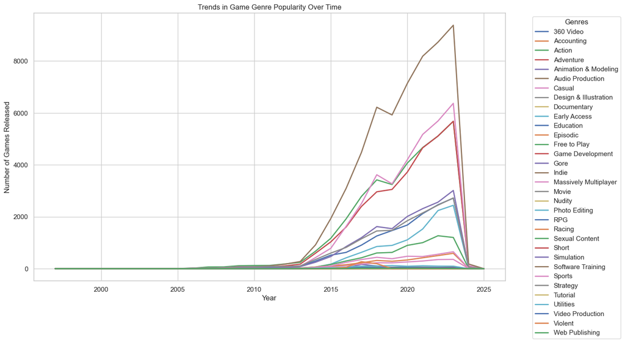

```python
# Visualization
sns.set(style='whitegrid')
pivot_data = year_genre_counts.pivot(index='Year', columns='Genres', values='Count').fillna(0)
plt.figure(figsize=(14, 8))
for column in pivot_data.columns:
    plt.plot(pivot_data.index, pivot_data[column], marker='', linewidth=2, label=column)

plt.title('Trends in Game Genre Popularity Over Time')
plt.xlabel('Year')
plt.ylabel('Number of Games Released')
plt.legend(title='Genres', bbox_to_anchor=(1.05, 1), loc='upper left')
plt.show()
```

This plot shows the yearly total of games launched in each genre. We can see how the popularity of each genre has changed over time by looking at the lines that represent the various genres. Trends such as rises or falls in the quantity of games launched in particular genres are visible. "Indie", "Casual" and "Adventure" games have seen high popularity.

```python
# Count the frequency of each genre
genre_counts = exploded_genres['Genres'].value_counts()
```

```python
# Display the most common genre
main_genre = genre_counts.idxmax()
print("The main genre across all games is:", main_genre)
```

```
The main genre across all games is: Indie
```

We can see that the main and most common genre amongst all is Indie.

#### 2. Player Engagement: Correlation with Game Features

```python
# Converting 'Average playtime forever' and 'Median playtime forever' to numeric values
data['Average playtime forever'] = pd.to_numeric(data['Average playtime forever'], errors='coerce')
data['Median playtime forever'] = pd.to_numeric(data['Median playtime forever'], errors='coerce')
```

```python
# Calculating correlations
features = ['Price', 'Positive', 'Negative', 'User score', 'Achievements', 'DLC count']
correlation_matrix = data[['Average playtime forever', 'Median playtime forever'] + features].corr()
print(correlation_matrix)
```

```
                          Average playtime forever  Median playtime forever  \
Average playtime forever                  1.000000                 0.884408
Median playtime forever                   0.884408                 1.000000
Price                                     0.062672                 0.041303
Positive                                  0.203896                 0.034883
Negative                                  0.194859                 0.036292
User score                                0.000017                 0.000291
Achievements                              0.014197                 0.006498
DLC count                                 0.035371                 0.015367

                             Price  Positive  Negative  User score  \
Average playtime forever  0.062672  0.203896  0.194859    0.000017
Median playtime forever   0.041303  0.034883  0.036292    0.000291
Price                     1.000000  0.029271  0.025202   -0.000718
Positive                  0.029271  1.000000  0.784008   -0.000745
Negative                  0.025202  0.784008  1.000000   -0.000622
User score               -0.000718 -0.000745 -0.000622    1.000000
Achievements              0.006826  0.013558  0.009872    0.002270
DLC count                 0.042934  0.019362  0.017516    0.000622

                          Achievements  DLC count
Average playtime forever      0.014197   0.035371
Median playtime forever       0.006498   0.015367
Price                         0.006826   0.042934
Positive                      0.013558   0.019362
Negative                      0.009872   0.017516
User score                    0.002270   0.000622
Achievements                  1.000000   0.033534
DLC count                     0.033534   1.000000
```

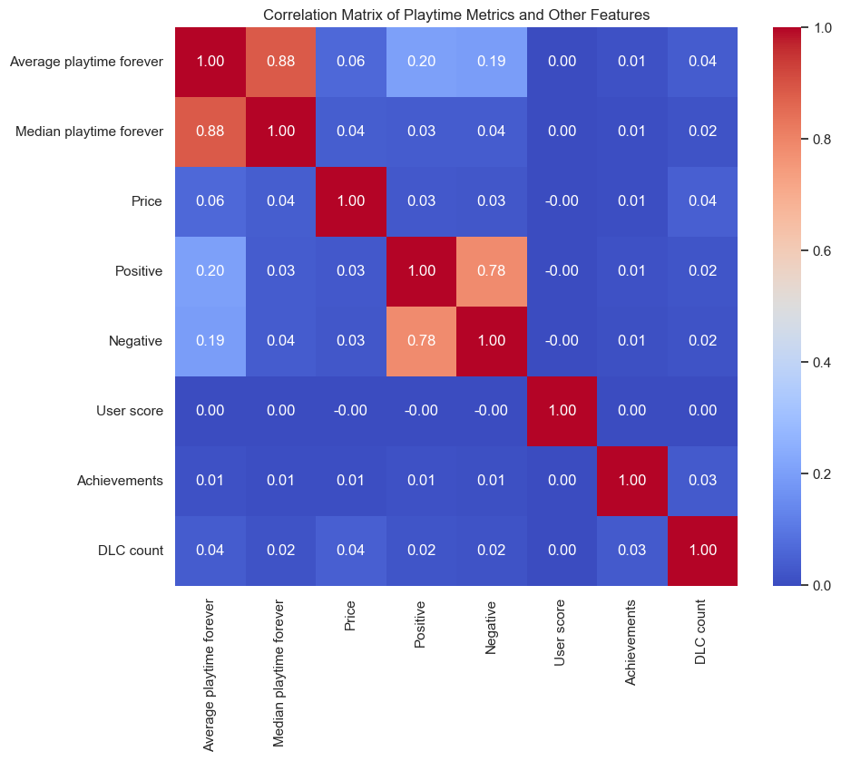

```python
# Creating a heatmap for the correlation matrix
sns.set(style='white')
plt.figure(figsize=(10, 8))
sns.heatmap(correlation_matrix, annot=True, fmt='.2f', cmap='coolwarm', cbar=True)
plt.title('Correlation Matrix of Playtime Metrics and Other Features')
plt.show()
```

The correlation matrix between playtime metrics and other variables is shown in this heatmap. The correlations are shown visually in this heatmap, where stronger positive correlations are denoted by warmer colors and weaker or negative correlations by cooler colors. The mild associations with 'Positive' and 'Negative' evaluations are clear, as is the substantial correlation between 'Average playtime forever' and 'Median playtime forever'.

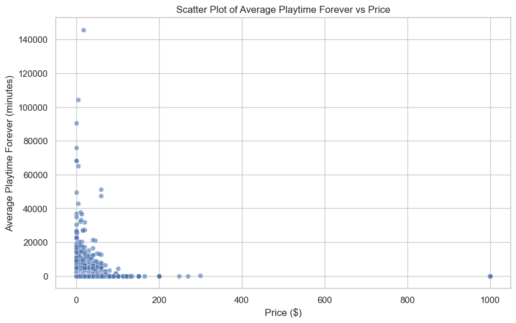

```python
# Setting the aesthetic style of the plots
sns.set(style='whitegrid')

# Creating a scatter plot for 'Average playtime forever' vs 'Price'
plt.figure(figsize=(10, 6))
sns.scatterplot(data=data, x='Price', y='Average playtime forever', alpha=0.6)
plt.title('Scatter Plot of Average Playtime Forever vs Price')
plt.xlabel('Price ($)')
plt.ylabel('Average Playtime Forever (minutes)')
plt.show()
```

With respect to price and average playtime, this graphic displays the distribution of games over time. The scatter plot's dispersion of points over different price ranges and lack of identifiable pattern implies that there isn't a strong linear relationship between a game's pricing and the average amount of time people spend playing it.

#### 3. Economic Insights: Impact of Pricing on Ratings and Ownership

```python
# Converting 'Estimated owners' to a numeric value representing the average of the estimated range
data['Estimated owners numeric'] = data['Estimated owners'].str.split('-').apply(lambda x: (int(x[0]) + int(x[1])) / 2)
```

```python
# Calculating correlations
features_to_correlate = ['Price', 'User score', 'Positive', 'Negative', 'Estimated owners numeric']
correlation_matrix_owners = data[features_to_correlate].corr()
print(correlation_matrix_owners)
```

```
                             Price  User score  Positive  Negative  \
Price                     1.000000   -0.000718  0.029271  0.025202
User score               -0.000718    1.000000 -0.000745 -0.000622
Positive                  0.029271   -0.000745  1.000000  0.784008
Negative                  0.025202   -0.000622  0.784008  1.000000
Estimated owners numeric  0.035169   -0.001393  0.668159  0.642197

                          Estimated owners numeric
Price                                     0.035169
User score                               -0.001393
Positive                                  0.668159
Negative                                  0.642197
Estimated owners numeric                  1.000000
```

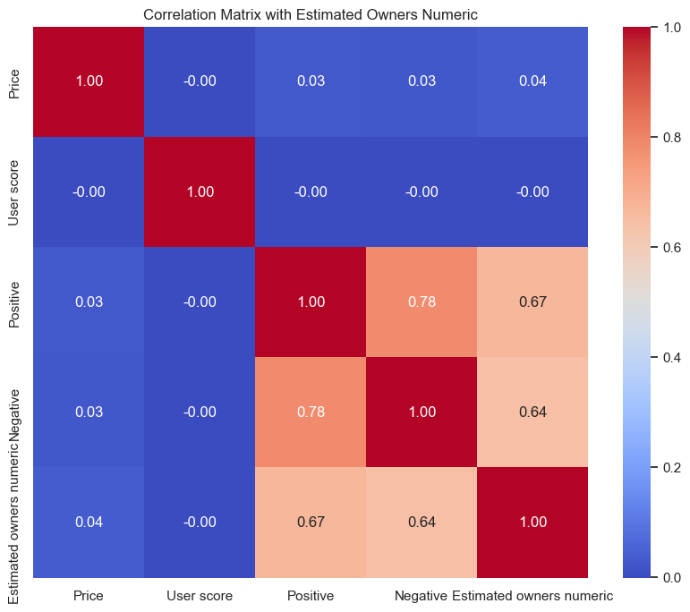

```python
# Creating a heatmap for the new correlation matrix
sns.set(style='white')
plt.figure(figsize=(10, 8))
sns.heatmap(correlation_matrix_owners, annot=True, fmt='.2f', cmap='coolwarm', cbar=True)
plt.title('Correlation Matrix with Estimated Owners Numeric')
plt.show()
```

The associations between "Price," "User score," "Positive," "Negative," and "Estimated owners numeric" are highlighted in this heatmap, which offers a visual depiction of the correlations. Positive and negative review counts clearly correlate more strongly with "Estimated owners numeric," suggesting that games with a larger number of owners typically receive more reviews.

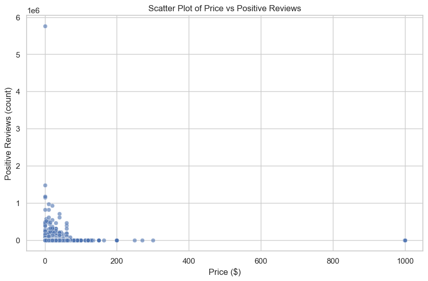

```python
# Creating a scatter plot for 'Price' vs 'Positive' reviews
sns.set(style='whitegrid')
plt.figure(figsize=(10, 6))
sns.scatterplot(data=data, x='Price', y='Positive', alpha=0.6)
plt.title('Scatter Plot of Price vs Positive Reviews')
plt.xlabel('Price ($)')
plt.ylabel('Positive Reviews (count)')
plt.show()
```

This graph displays the distribution of games according to their price and the number of favorable reviews. While there are games at different price points getting a range of positive ratings, the scatter plot indicates that there isn't a clear linear link showing that higher costs result in more positive reviews. The distribution of data points over the pricing range suggests that user reception varies depending on the cost of the game.

#### 4. Analyzing different Operating Systems

```python
# Count of games supporting each OS
windows_count = data['Windows'].sum()
mac_count = data['Mac'].sum()
linux_count = data['Linux'].sum()
```

```python
print('Number of games supporting Windows:', windows_count)
print('Number of games supporting Mac:', mac_count)
print('Number of games supporting Linux:', linux_count)
```

```
Number of games supporting Windows: 85073
Number of games supporting Mac: 16393
Number of games supporting Linux: 11196
```

```python
# Descriptive statistics for games supporting each OS
windows_stats = data[data['Windows']].describe()
mac_stats = data[data['Mac']].describe()
linux_stats = data[data['Linux']].describe()
```

```python
print('Descriptive Statistics for Windows-supported games:\
', windows_stats)
print('Descriptive Statistics for Mac-supported games:\
', mac_stats)
print('Descriptive Statistics for Linux-supported games:\
', linux_stats)
```

```
Descriptive Statistics for Windows-supported games:               AppID       Peak CCU  Required age         Price     DLC count  \
count  8.507300e+04   85073.000000  85073.000000  85073.000000  85073.000000
mean   1.355774e+06     134.920457      0.312473      7.189650      0.543592
std    6.949912e+05    5404.500935      2.253569     12.343643     13.723638
min    1.000000e+01       0.000000      0.000000      0.000000      0.000000
25%    7.724800e+05       0.000000      0.000000      0.990000      0.000000
50%    1.331620e+06       0.000000      0.000000      4.490000      0.000000
75%    1.918460e+06       1.000000      0.000000      9.990000      0.000000
max    2.765800e+06  872138.000000     21.000000    999.980000   2366.000000

         User score      Positive       Negative  Score rank  Achievements  \
count  85073.000000  8.507300e+04   85073.000000   44.000000  85073.000000
mean       0.039836  9.588914e+02     159.824163   98.909091     19.865374
std        1.791329  2.436349e+04    4575.389535    0.857747    171.476643
min        0.000000  0.000000e+00       0.000000   97.000000      0.000000
25%        0.000000  0.000000e+00       0.000000   98.000000      0.000000
50%        0.000000  7.000000e+00       2.000000   99.000000      0.000000
75%        0.000000  4.500000e+01      14.000000  100.000000     18.000000
max      100.000000  5.764420e+06  895978.000000  100.000000   9821.000000

       Recommendations  Average playtime forever  Average playtime two weeks  \
count     8.507300e+04              85073.000000                85073.000000
mean      7.757864e+02                104.761664                   10.683871
std       1.789652e+04               1142.647069                  188.873193
min       0.000000e+00                  0.000000                    0.000000
25%       0.000000e+00                  0.000000                    0.000000
50%       0.000000e+00                  0.000000                    0.000000
75%       0.000000e+00                  0.000000                    0.000000
max       3.441592e+06             145727.000000                19159.000000

       Median playtime forever  Median playtime two weeks          Year  \
count             85073.000000               85073.000000  85073.000000
mean                 93.343987                  11.471372   2019.803275
std                1510.997266                 205.409039      2.894953
min                   0.000000                   0.000000   1997.000000
25%                   0.000000                   0.000000   2018.000000
50%                   0.000000                   0.000000   2020.000000
75%                   0.000000                   0.000000   2022.000000
max              208473.000000               19159.000000   2025.000000

```

[output cut: 92 more lines]

```
min                   0.000000                   0.000000   1997.000000
25%                   0.000000                   0.000000   2016.000000
50%                   0.000000                   0.000000   2019.000000
75%                  59.000000                   0.000000   2021.000000
max              136291.000000               10012.000000   2024.000000

       Estimated owners numeric
count              1.119600e+04
mean               1.960727e+05
std                2.117738e+06
min                0.000000e+00
25%                1.000000e+04
50%                1.000000e+04
75%                3.500000e+04
max                1.500000e+08
```

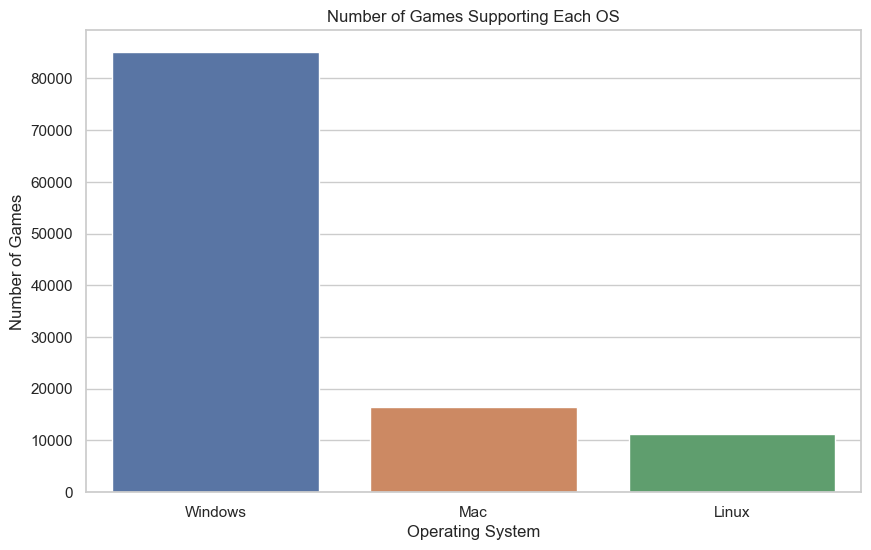

```python
# Bar plot for the number of games supporting each OS
os_support = pd.DataFrame({'OS': ['Windows', 'Mac', 'Linux'], 'Count': [windows_count, mac_count, linux_count]})
sns.set(style='whitegrid')
plt.figure(figsize=(10, 6))
bar_plot = sns.barplot(x='OS', y='Count', data=os_support)
plt.title('Number of Games Supporting Each OS')
plt.xlabel('Operating System')
plt.ylabel('Number of Games')
plt.show()
```

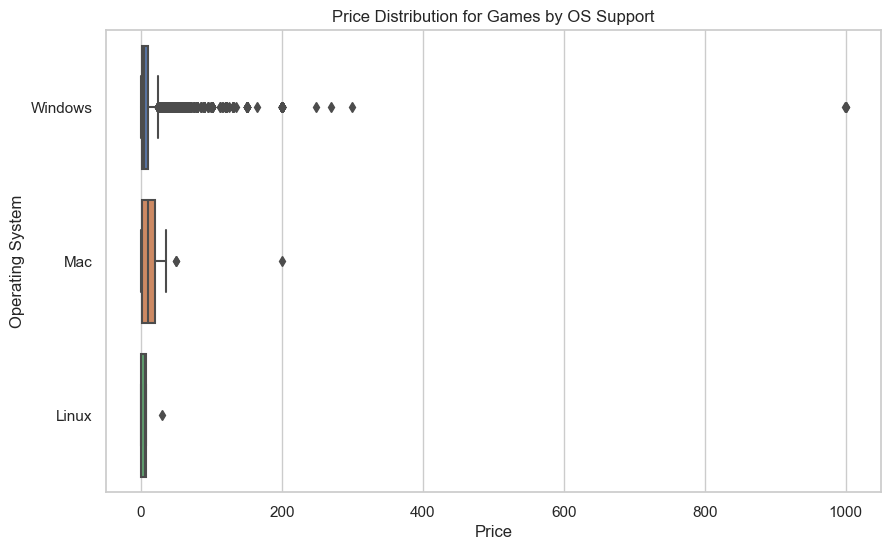

```python
# Visualizing with the help of a box plot
data['OS'] = data.apply(lambda row: 'Windows' if row['Windows'] else ('Mac' if row['Mac'] else 'Linux'), axis=1)
plt.figure(figsize=(10, 6))
box_plot = sns.boxplot(data=data, x='Price', y='OS', orient='h', order=['Windows', 'Mac', 'Linux'])
plt.title('Price Distribution for Games by OS Support')
plt.xlabel('Price')
plt.ylabel('Operating System')
plt.show()
```

#### 5. Trend with adult content in the games.

One observatiion that we made was that "Notes" column contains 13,021 values in it and rest all were null values. But intrestingly, we found that each time there was a note mentioned for a particular game, its intentions were to make the users aware about or give warning for either sexual content, abusive language, violence, drug use, alcohol comsumption, blood shed, etc. which indicates that the game is suggested to be played by adults above 18 years of age.

```python
# Convert 'Release date' to datetime and extract the year
data['Release Year'] = pd.to_datetime(data['Release date'], errors='coerce').dt.year

# Filter rows where 'Notes' column contains 'adult'
adult = data[data['Notes'].str.contains('adult', case=False, na=False)]

# Count the number of adult games per year
games_adult_per_year = adult.groupby('Release Year').size()
```

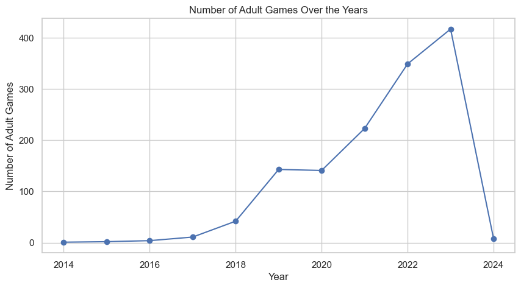

```python
# Plotting
plt.figure(figsize=(10, 5), facecolor='white')
plt.plot(games_adult_per_year.index, games_adult_per_year.values, marker='o', linestyle='-')
plt.title('Number of Adult Games Over the Years')
plt.xlabel('Year')
plt.ylabel('Number of Adult Games')
plt.grid(True)
plt.show()
```

### Conclusion

From the perspective of business, these visualizations provide the following insights for both Steam users and game developers:

**Popularity of Genres and Development Focus**: A robust market demand for games in the "Indie," "Casual," and "Adventure" genres is indicated by their popularity. To potentially capitalize on current player interest, game developers should think about concentrating their efforts on creating games in these genres.  
**Market Trends and Adaptation**: Game creators can keep up with current trends in the market by keeping an eye on how the popularity of a genre changes over time. Remaining competitive in the market may depend on developers responding to these trends by refocusing their efforts on developing games in emerging genres or altering current releases to suit evolving player tastes.  
**Price-Playtime link**: It appears that basing prices exclusively on projected playtime may not be the best course of action because there is no discernible linear link between average playtime and game pricing. When deciding on pricing options, game makers should take into account a number of aspects, including target demographic, genre, and quality.  
**Ownership and User Reviews**: The value of user involvement and feedback is highlighted by the association between the number of user reviews and the expected number of game owners. Boosting user reviews and cultivating a strong rapport with the player base can help games on the platform become more visible, sell more, and be more successful overall.  
**Adult Content and Target Audience**: There appears to be a rising market for games with mature themes, as seen by the rise in adult-themed games over time and the frequency of content warnings. It is imperative for game producers to use caution while creating material, taking into account the tastes and interests of adult players.  
**Platform-Specific Points to Remember**: The difference in game prices between operating systems emphasizes how crucial it is to comprehend platform-specific market dynamics. It is recommended that game developers and the Steam platform customize their pricing plans and promotional tactics to accommodate variations in player behavior and purchasing power among different operating systems.

To sum up, these observations highlight how important it is for game developers and the Steam platform to be aware of the market, engage players, and make strategic decisions. Developers can better position their games for success in a competitive and dynamic gaming landscape by utilizing these findings, and platforms such as Steam can adapt their services and features to better suit the varied demands and tastes of their user base.